# anantharam_subramanian_nlp_hw3

## Anantharam(Ananth) Subramanian

## Natural Language Processing- Homework #3

```python
import nltk
```

## Question 1

1. Compare your given name with your nickname (if you don’t have a nickname, invent one for this assignment) by answering the following questions: a. What is the edit distance between your nickname and your given name? b. What is the percentage string match between your nickname and your given name? Show your work for both calculations.

## Answer

Edit distance between two strings is calculated by using Levenshtein distance. The distance between the strings are dependent on the number of edits that are needed to match the words ie. insertion, deletion and substitution. I first manually calculated the distance using the following concept:

1. If the characters at a particular position is same, go with the diagonal value
2. If the characters are different, find the minimum value to the left, diagonal and top and then add one.

## Reference to the image below that is hand drawn

1. We have two strings "trial" and "trail". The edit distance calculated manually is 2 as indicated in the image
2. Let us review the value for the character a. As per the diagram it is "1". How did we arrive at the value 1? Since both the characters are same, we go with the diagonal value ie. 1. Please refer to the cell "r" and "i".
3. Now let us review the value for the character "l" and "a" which is 2. How did we arrive at the value 2? The values to the left is "1", diagnol is "2" and above is "3". The minimum is 1 and add 1 and that makes 2.

## Formula (consider strings S1 and S2)

If S1[i] = S2[j], consider the diagonal value T[i][j] = T[i-1][j-1] Else T[i][j] = min(T[i-1][j], T[i-1][j-1],T[i][j-1]) +1

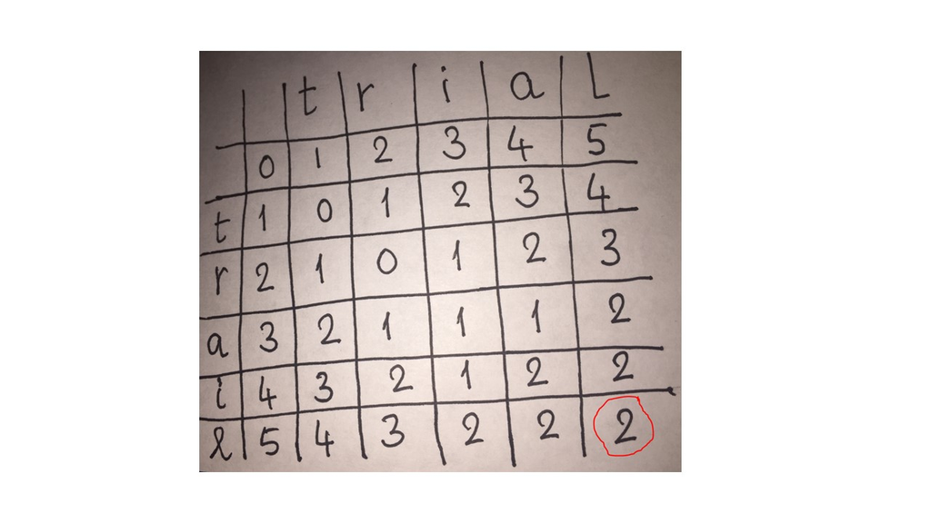

```python
from IPython.display import Image
Image(filename = "C:\\Users\\anant\\Documents\\NLP\\hw3\lavenstein.jpg", width=800, height=800)
```

## The above concept is validated using Levenshtein package (distance & ratio); Unfortunately the Levenshtein package does not work in Jupyter notebook. However, it does work in Spyder. Screenshots of the images are below. The edit distance between my name and nickname and the percentage of similarlity are calculated.

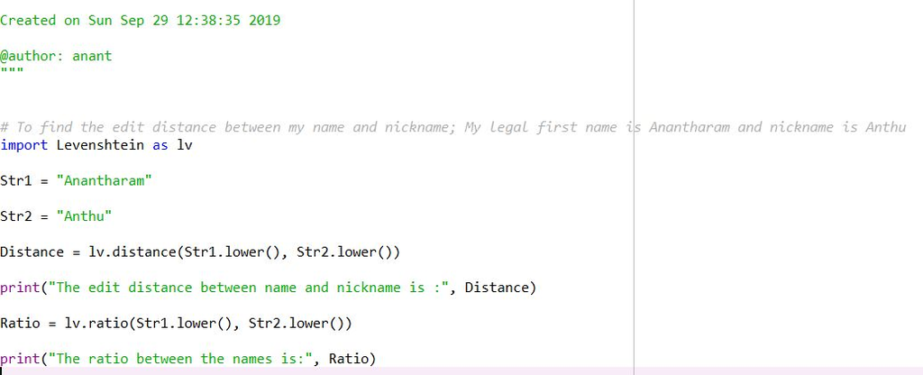

```python
Image(filename = "C:\\Users\\anant\\Documents\\NLP\\hw3\levenshtein_dist_ratio.JPG", width=800, height=800)
```

## Output: The edit distance is 6 and the percentage string match is 53.3%

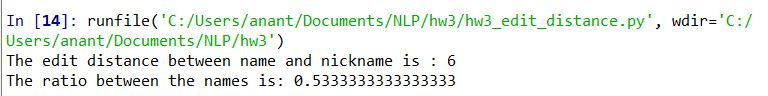

```python
Image(filename = "C:\\Users\\anant\\Documents\\NLP\\hw3\output_distance_ratio.JPG", width=800, height=800)
```

## Validation with Lavenshtein package is also done for the words "trial" and "trail" for which the edit distance was previously calculated manually. The result tallies.

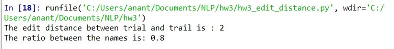

```python
Image(filename = "C:\\Users\\anant\\Documents\\NLP\\hw3\\trail_trial.JPG", width=800, height=800)
```

## Question 2: Find a friend (or family member or classmate) who you know has read a certain book. Without your friend knowing, copy the first two sentences of that book. Now rewrite the words from those sentences, excluding stop words. Now tell your friend to guess which book the words are from by reading them just that list of words. Did you friend correctly guess the book on the first try? What did he or she guess? Explain why you think you friend either was or was not able to guess the book from hearing the list of words.

## Excerpts from the book "The Dressmaker's gift" are read from a text file. This is then followed by tokenization. Stopwords are then removed and shown to my friend.

```python
f= open('C:\\Users\\anant\\Documents\\NLP\\hw3\\potter.txt')
```

```python
raw = f.read()
```

```python
print(raw)
```

```
From a distance, the midnight blue dress looks as though it has been cut from one single piece of silk. Its graceful lines drape and flow, skimming the form of the mannequin on which it is displayed. But if you look more closely, you will see that this is an illusion. The dress has been pieced toget…
```

```python
tokens = nltk.word_tokenize(raw)
```

```python
print(tokens)
```

```
['From', 'a', 'distance', ',', 'the', 'midnight', 'blue', 'dress', 'looks', 'as', 'though', 'it', 'has', 'been', 'cut', 'from', 'one', 'single', 'piece', 'of', 'silk', '.', 'Its', 'graceful', 'lines', 'drape', 'and', 'flow', ',', 'skimming', 'the', 'form', 'of', 'the', 'mannequin', 'on', 'which', 'i…
```

```python
from nltk.corpus import stopwords
```

```python
w = stopwords.words('english')
```

```python
len(w)
```

```
179
```

```python
print(w)
```

```
['i', 'me', 'my', 'myself', 'we', 'our', 'ours', 'ourselves', 'you', "you're", "you've", "you'll", "you'd", 'your', 'yours', 'yourself', 'yourselves', 'he', 'him', 'his', 'himself', 'she', "she's", 'her', 'hers', 'herself', 'it', "it's", 'its', 'itself', 'they', 'them', 'their', 'theirs', 'themselve…
```

```python
def content_fraction(text):
    stopwords = nltk.corpus.stopwords.words('english')
    content = [w for w in text if w.lower() not in stopwords]
    return content
```

```python
content_without_stop_words = content_fraction(tokens)
```

```python
print(content_without_stop_words)
```

```
['distance', ',', 'midnight', 'blue', 'dress', 'looks', 'though', 'cut', 'one', 'single', 'piece', 'silk', '.', 'graceful', 'lines', 'drape', 'flow', ',', 'skimming', 'form', 'mannequin', 'displayed', '.', 'look', 'closely', ',', 'see', 'illusion', '.', 'dress', 'pieced', 'together', 'scraps', 'off-…
```

## My friend could not make out the book based on the words that were read to him ie. after removing the stopwords. He says these words are more common and he can relate to multiple books rather than "The DressMaker's Gift". Reading more on this, I came to know that stopwords add a flow to a sentence and make identification easier. I understand that removing stopwords helps more in the classification problem for example sentiment analysis where we need to identify if a particular review is good or bad. Removing the stopwords would yield words like poor, good, etc. and can be used to analyse the sentiment.

## Question 3: Run one of the stemmers available in Python. Run the same two sentences from question 2 above through the stemmer and show the results. How many of the outputted stems are valid morphological roots of the corresponding words? Express this answer as a percentage.

```python
from nltk.stem import PorterStemmer as ps
from nltk.tokenize import word_tokenize
```

```python
words1 = word_tokenize(raw)
print(words1)
ps = PorterStemmer()
```

```
['From', 'a', 'distance', ',', 'the', 'midnight', 'blue', 'dress', 'looks', 'as', 'though', 'it', 'has', 'been', 'cut', 'from', 'one', 'single', 'piece', 'of', 'silk', '.', 'Its', 'graceful', 'lines', 'drape', 'and', 'flow', ',', 'skimming', 'the', 'form', 'of', 'the', 'mannequin', 'on', 'which', 'i…
```

```python
for w in words1:
    print(w, " : ", ps.stem(w))
```

```
From  :  from
a  :  a
distance  :  distanc
,  :  ,
the  :  the
midnight  :  midnight
blue  :  blue
dress  :  dress
looks  :  look
as  :  as
though  :  though
it  :  it
has  :  ha
been  :  been
cut  :  cut
from  :  from
one  :  one
single  :  singl
piece  :  piec
of  :  of
silk  :  silk
.  :  .
Its  :  it
graceful  :  grace
lines  :  line
drape  :  drape
and  :  and
flow  :  flow
,  :  ,
skimming  :  skim
the  :  the
form  :  form
of  :  of
the  :  the
mannequin  :  mannequin
on  :  on
which  :  which
it  :  it
is  :  is
displayed  :  display
```

[output cut: 27 more lines]

```
,  :  ,
sewn  :  sewn
edge  :  edg
to  :  to
edge  :  edg
so  :  so
cleverly  :  cleverli
that  :  that
they  :  they
have  :  have
been  :  been
transformed  :  transform
into  :  into
something  :  someth
else  :  els
```

```python
len(words1)
```

```
82
```

## Answer:

## The stemmer has successfully stemmed 10 words to the corresponding root word, example transformed to transform, displayed to display, closely to close, graceful as grace, etc. The percentage is around 0.13